# 2082022_analysis

Tanvi Ingle

2/10/2022

Libraries

Common Functions & Base directory

### **Objective**

Here I will analyze the results from the promoter optimization run on 2-08-2022. For this optimization attempt, I ran 5 scenarios with unique distributions for promoters A, B, and D. Each scenario was simmulated 10 times. Each simulation was run for 300 generations.

The optimization algorithm differs from that run on 1-26-2022 in two main ways:

1. The error at generation zero does not start at e^10. Hopefully this will allow the error values to converge faster.
2. Previously, when not all of the genes are expressed in the simulation, the reported error was -1. This caused a lot of ‘lost progress’. Now, the previous error from the most recent, valid pinetree simulation is reported.

Here are the details of each run. Each value represents the exponent on *e*, ie if uA = 11, then the mean strength of promoter A is e^11.

> Starting promoter distributions

| scenario | uA | oA | uB | oB | uD | oD |
| --- | --- | --- | --- | --- | --- | --- |
| A | 11.00 | 10 | 12.80 | 10 | 12.30 | 11 |
| B | 11.80 | 10 | 13.50 | 12 | 12.80 | 11 |
| C | 12.21 | 10 | 14.33 | 12 | 14.11 | 11 |
| D | 12.80 | 10 | 14.80 | 12 | 14.50 | 11 |
| E | 13.20 | 10 | 15.40 | 12 | 14.80 | 11 |

### **Scenario A**

> Scenario A - Change in Error over Generations

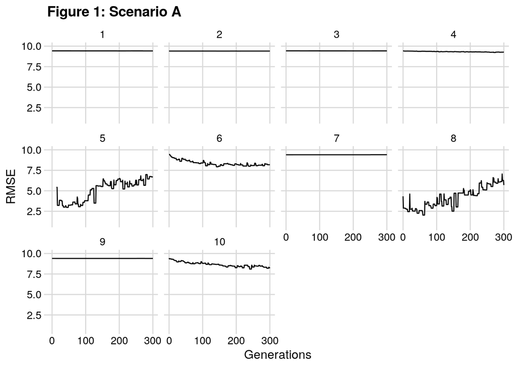

> Scenario A - Associated Errors for the best simulations

| sim | gen | pA | pB | pD | error |
| --- | --- | --- | --- | --- | --- |
| 5 | 43 | 169365.8 | 122360.6 | 4208754 | 2.97824 |
| 5 | 300 | 764433.5 | 725308.7 | 5373261 | 6.69519 |
| 6 | 141 | 746617.0 | 410320.1 | 1192140 | 7.93369 |
| 6 | 300 | 1046201.7 | 788917.9 | 2024631 | 8.18112 |
| 8 | 59 | 193090.7 | 386491.4 | 3484794 | 2.03546 |
| 8 | 300 | 662564.0 | 858375.5 | 4678063 | 5.70284 |
| 10 | 240 | 1066926.4 | 791951.8 | 1315291 | 8.10263 |
| 10 | 300 | 1166734.1 | 922425.7 | 1963320 | 8.20800 |

> Scenario A - Final Transcript Abundances for the best sims

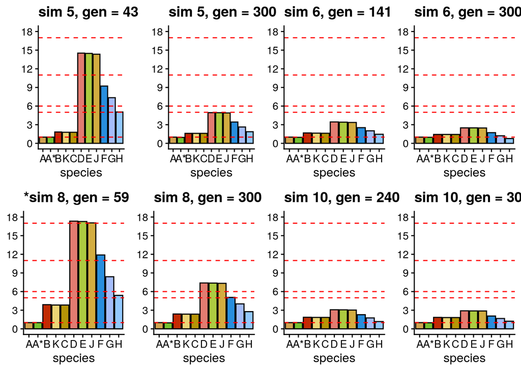

> Scenario A - Evolution of transcript abundances over generations for the best sims

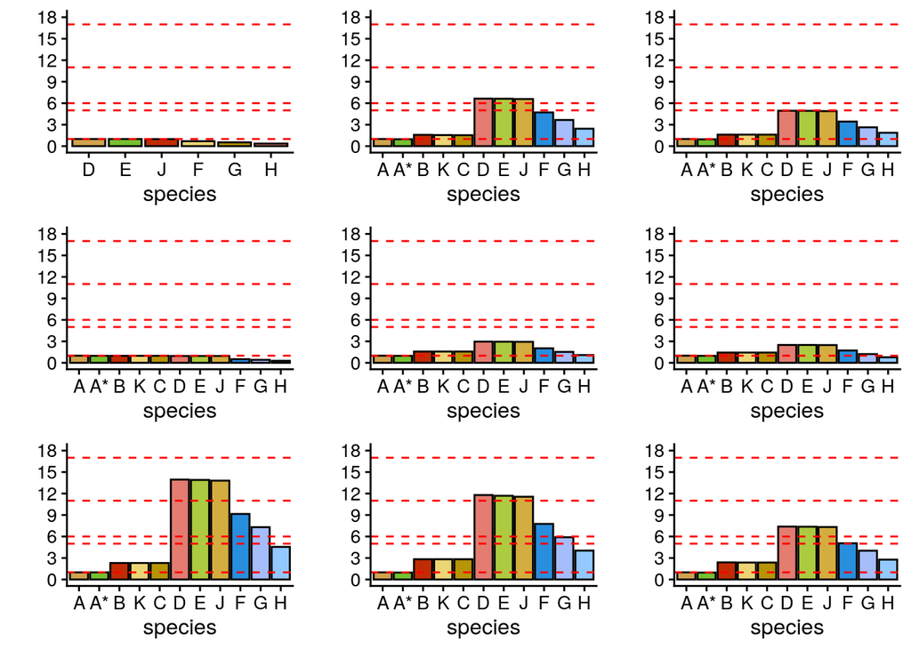

> Scenario A - Here is how the promoter values change over time

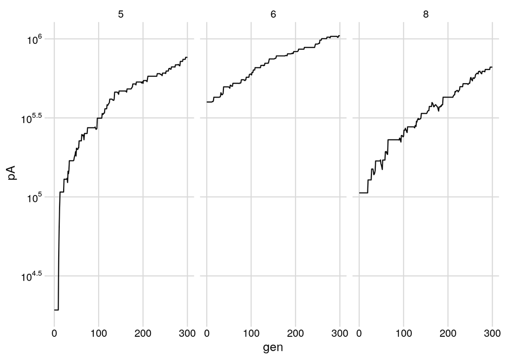

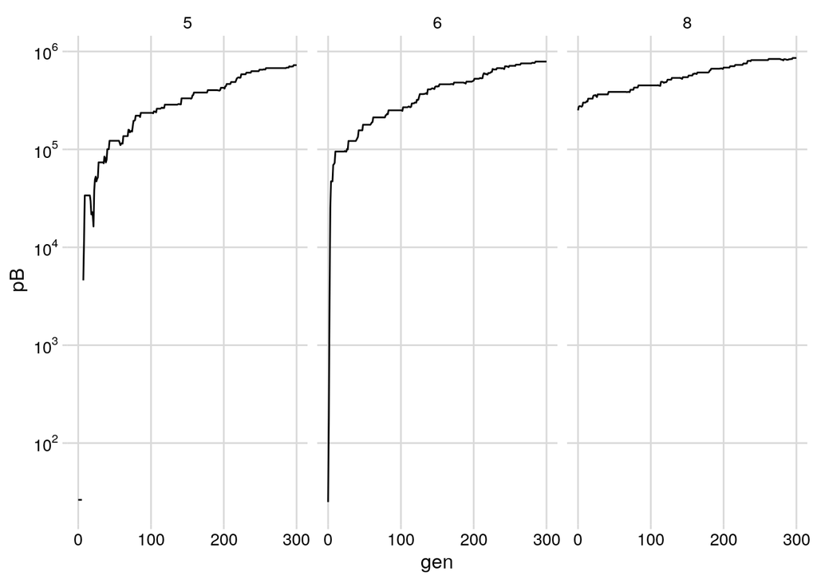

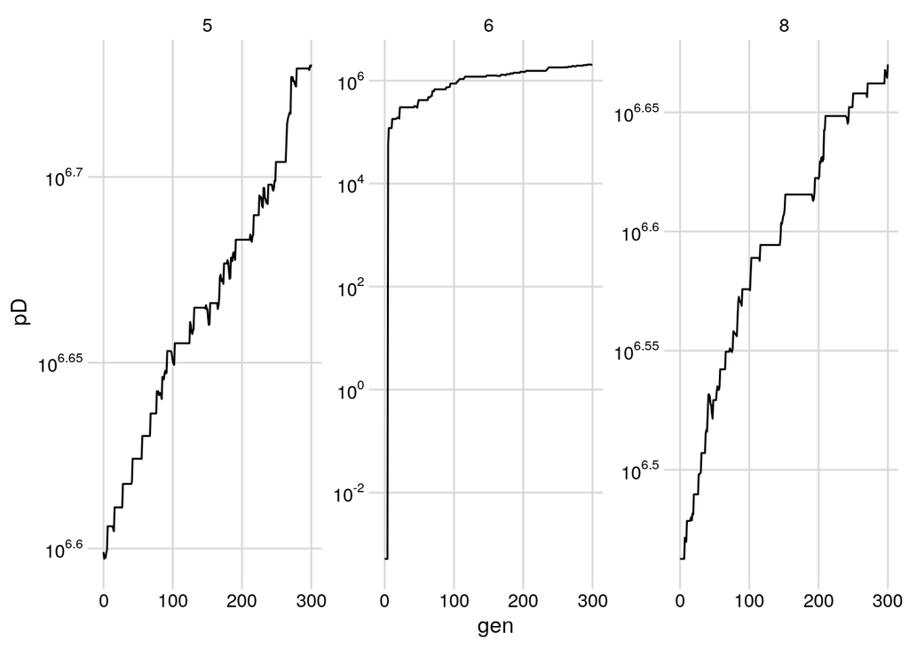

### **Scenario B**

> Scenario B - Change in Error over Generations

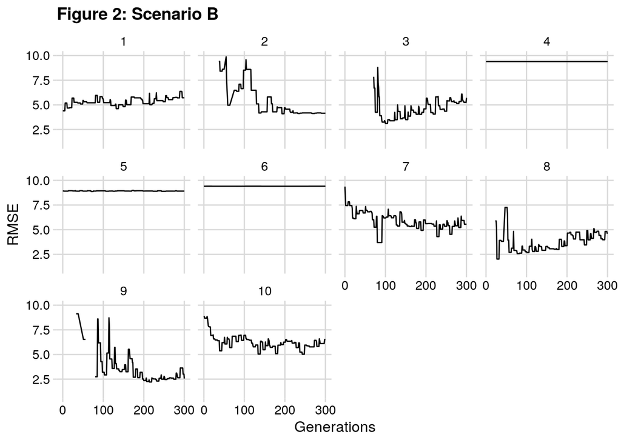

> Scenario B - Associated Errors for the best simulations

| sim | gen | pA | pB | pD | error |
| --- | --- | --- | --- | --- | --- |
| 1 | 0 | 1089712.29 | 528786.8 | 1437018503.0 | 4.40017 |
| 1 | 300 | 1692139.58 | 5212451.8 | 1438065024.9 | 5.72021 |
| 2 | 193 | 744030.73 | 113524424.9 | 672477690.5 | 4.10359 |
| 2 | 300 | 912793.68 | 114596360.6 | 672846039.5 | 4.15542 |
| 3 | 100 | 159582.79 | 1799950.1 | 794416.2 | 3.10927 |
| 3 | 300 | 693348.89 | 6948451.8 | 1356439.9 | 5.72452 |
| 7 | 80 | 292775.65 | 1422049.6 | 478571.8 | 3.69707 |
| 7 | 300 | 744760.19 | 5915913.4 | 1407927.0 | 5.54983 |
| 8 | 27 | 68751.19 | 766207.5 | 940745.9 | 2.02316 |
| 8 | 300 | 575873.22 | 4591572.3 | 2848596.5 | 4.63416 |
| 9 | 214 | 390885.81 | 4571721.0 | 9406640.0 | 2.20797 |
| 9 | 300 | 630575.01 | 5368207.0 | 9923252.3 | 2.55624 |
| 10 | 243 | 728298.70 | 4303052.2 | 1548045.0 | 5.02616 |
| 10 | 300 | 858106.59 | 5501591.6 | 1548045.0 | 6.51557 |

> Scenario B - Final Transcript Abundances for the best sims

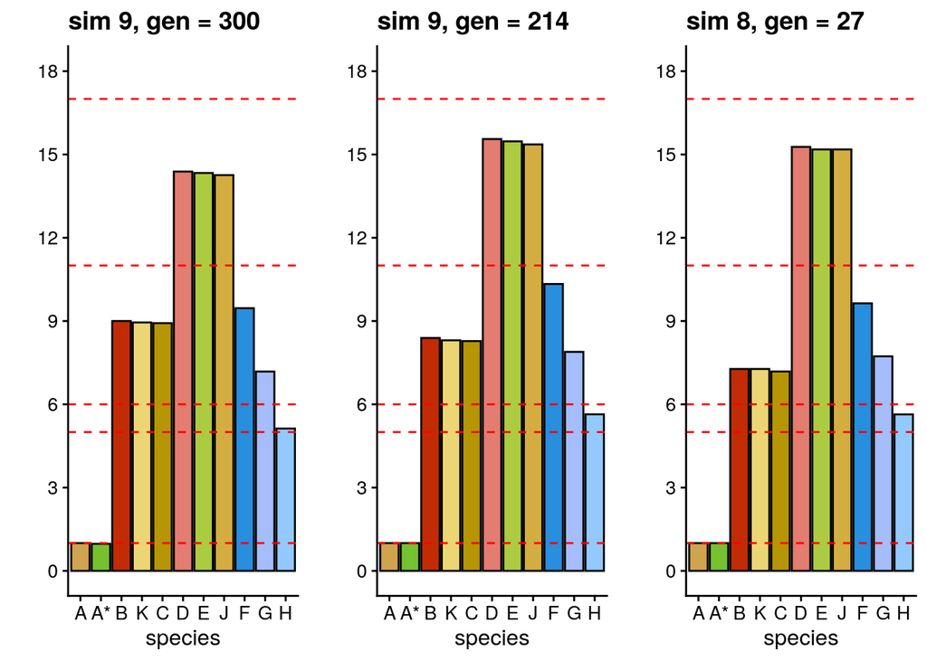

> Scenario B - Evolution of transcript abundances over generations for the best sims

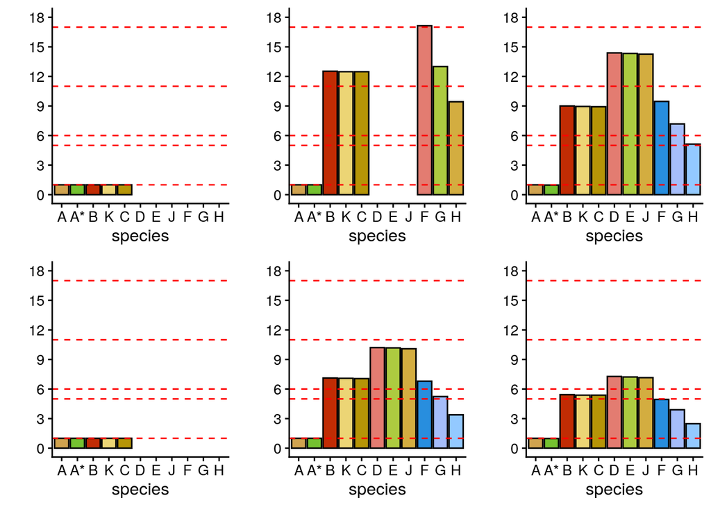

> Scenario B - Here is how the promoter values change over time

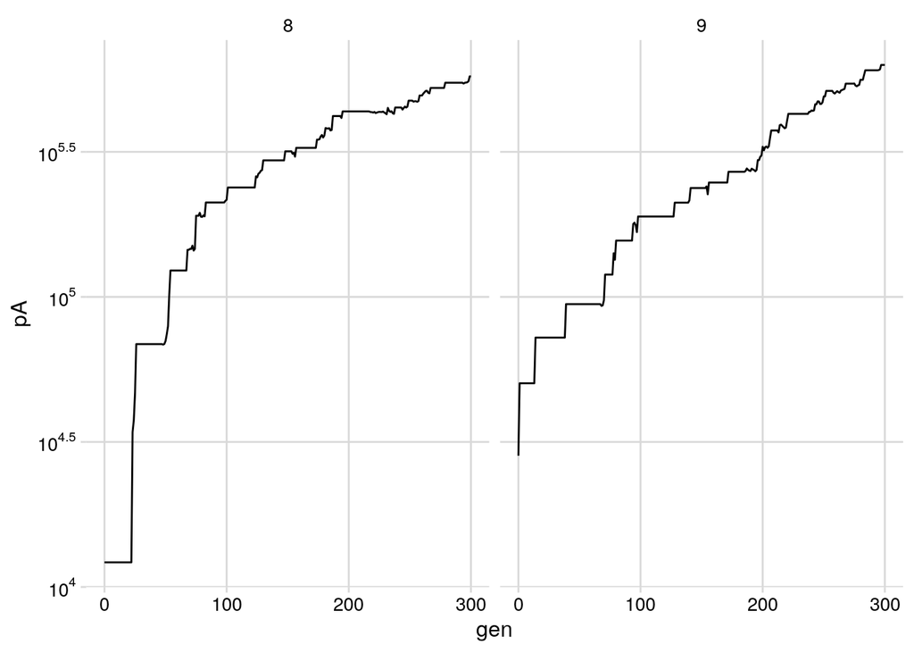

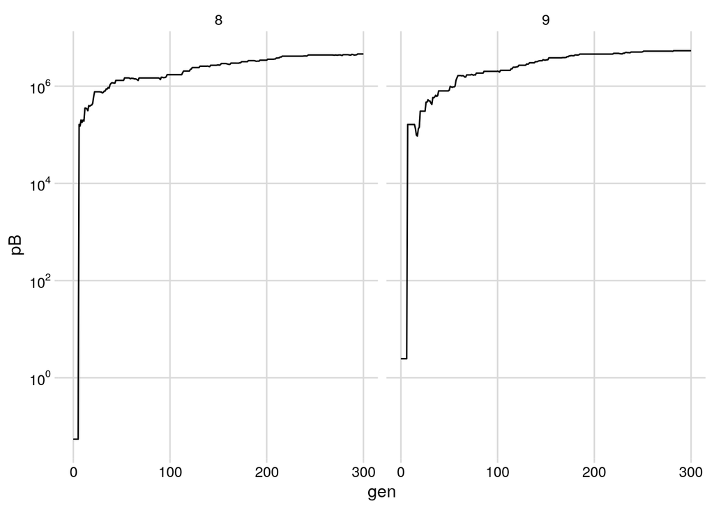

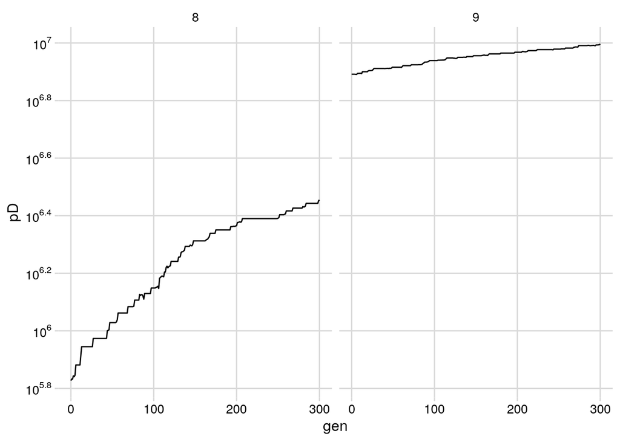

### **Scenario C**

> Scenario C - Change in Error over Generations

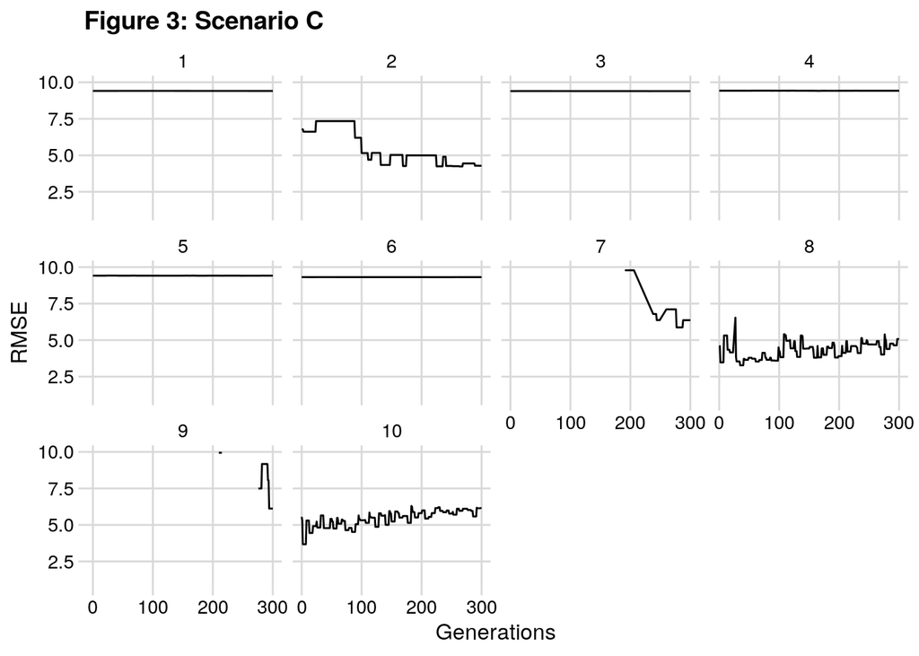

> Scenario C - Associated Errors for the best simulations

| sim | gen | pA | pB | pD | error |
| --- | --- | --- | --- | --- | --- |
| 2 | 263 | 903325.34 | 4.416248e+14 | 1.844043e+15 | 4.23811 |
| 2 | 300 | 960632.23 | 4.416248e+14 | 1.844043e+15 | 4.28538 |
| 7 | 277 | 583733.62 | 2.435367e+17 | 1.682223e+08 | 5.87283 |
| 7 | 300 | 610118.65 | 2.435367e+17 | 1.683270e+08 | 6.36449 |
| 8 | 35 | 71213.71 | 7.436605e+05 | 2.399482e+05 | 3.27234 |
| 8 | 300 | 595604.86 | 5.190282e+06 | 1.789332e+06 | 5.07459 |
| 9 | 294 | 570117.83 | 6.100881e+08 | 3.639618e+10 | 6.12017 |
| 9 | 300 | 570117.83 | 6.100881e+08 | 3.639622e+10 | 6.12017 |
| 10 | 2 | 815462.56 | 3.255096e+05 | 2.781297e+07 | 3.67688 |
| 10 | 300 | 1448956.05 | 5.852355e+06 | 2.930444e+07 | 6.15429 |

> Scenario C - Final Transcript Abundances for the best sims

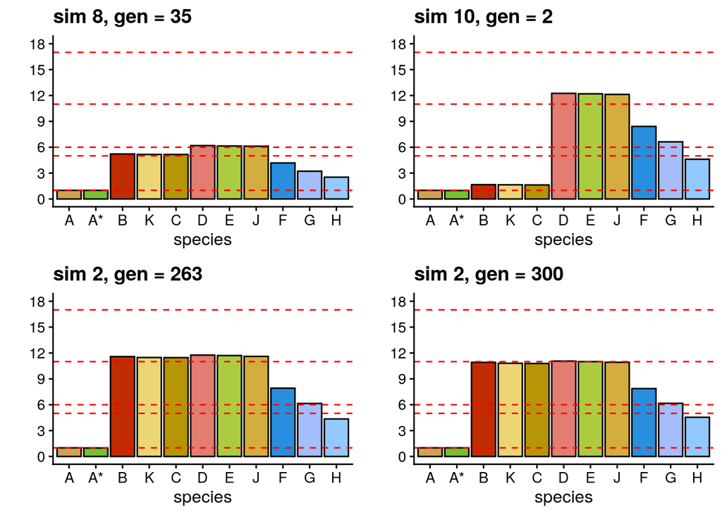

> Scenario C - Evolution of transcript abundances over generations for the best sims

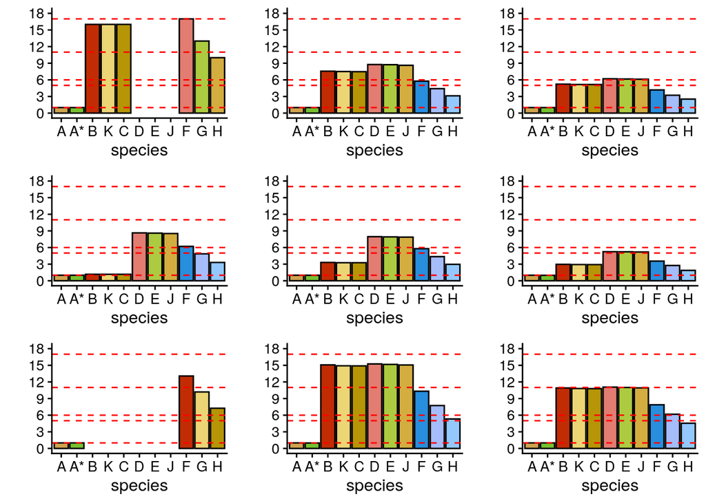

> Scenario C - Here is how the promoter values change over time

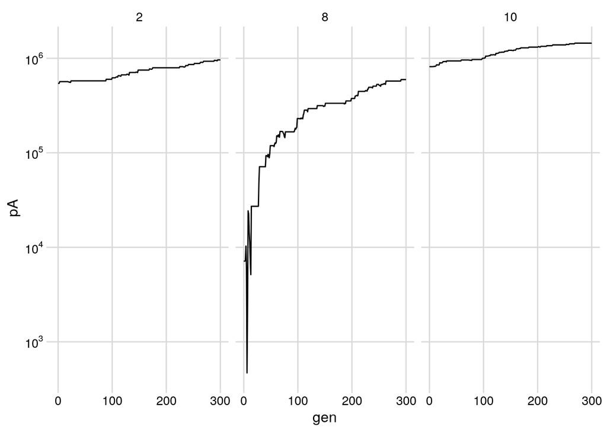

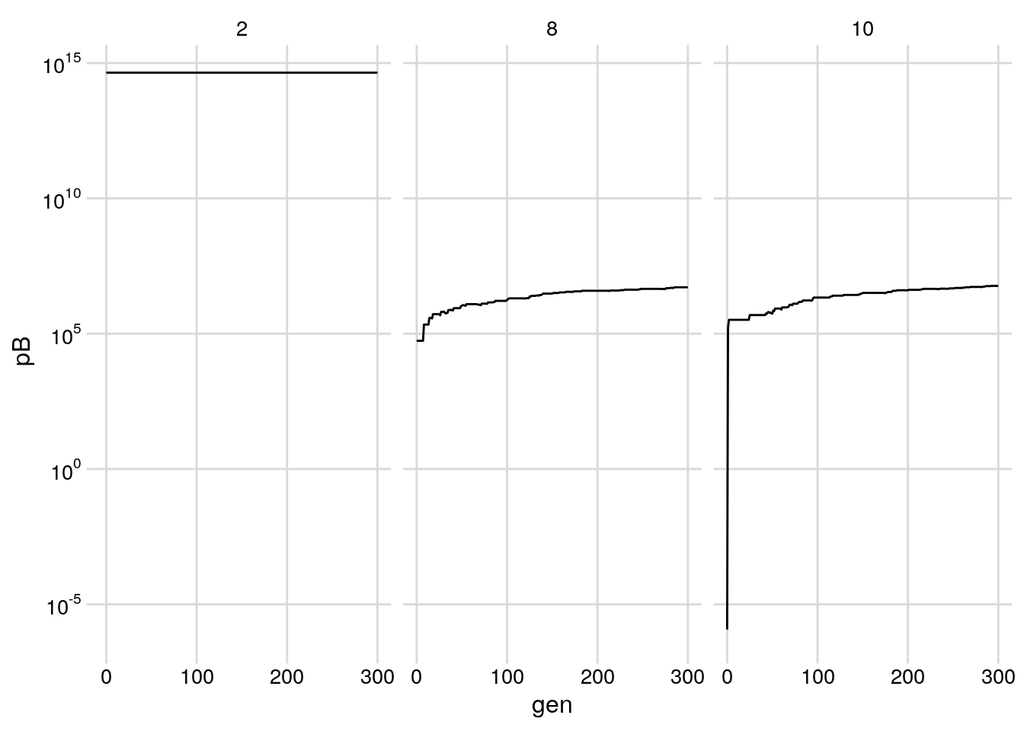

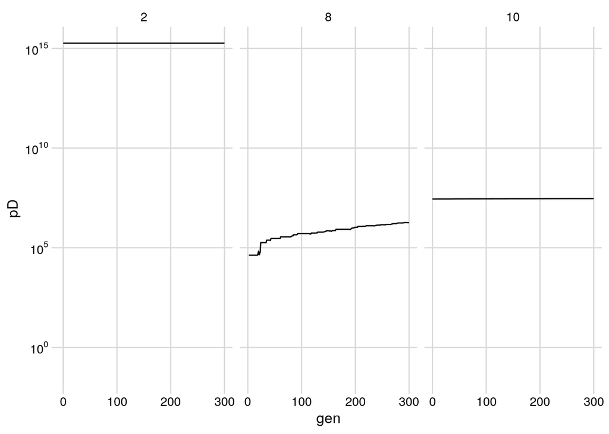

### **Scenario D**

> Scenario D - Change in Error over Generations

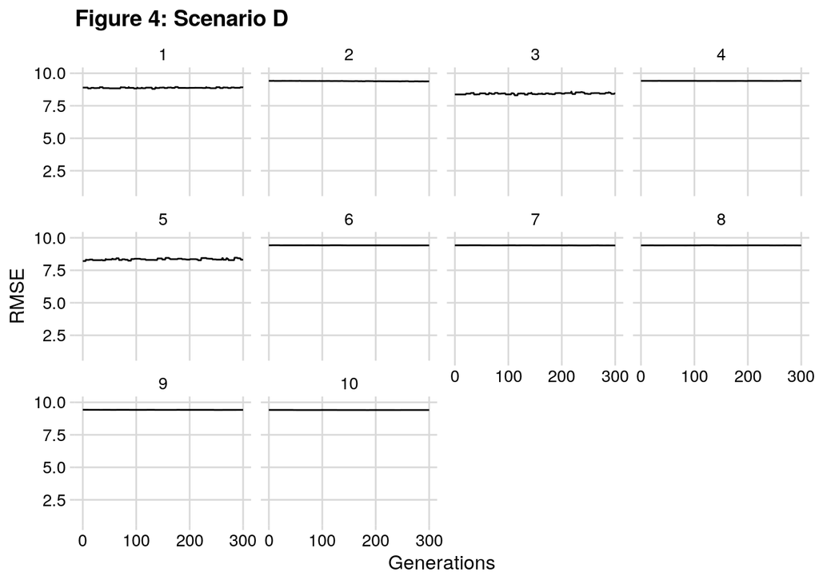

> Scenario D - Associated Errors for the best simulations

| sim | gen | pA | pB | pD | error |
| --- | --- | --- | --- | --- | --- |
| 3 | 112 | 4613906 | 1.168838e+07 | 19348102 | 8.30389 |
| 3 | 300 | 5101179 | 1.414266e+07 | 20097431 | 8.45405 |
| 5 | 0 | 4805287 | 5.072215e+02 | 3920443794 | 8.21132 |
| 5 | 300 | 5403606 | 4.189293e+06 | 3921498184 | 8.31367 |

> Scenario D - Final Transcript Abundances for the best sims

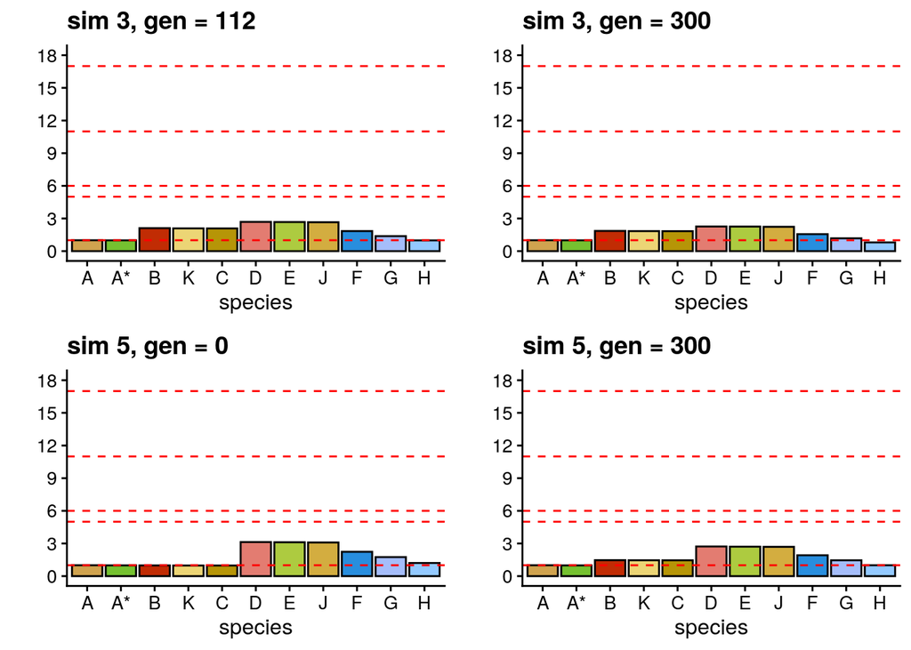

> Scenario D - Evolution of transcript abundances over generations for the best sims

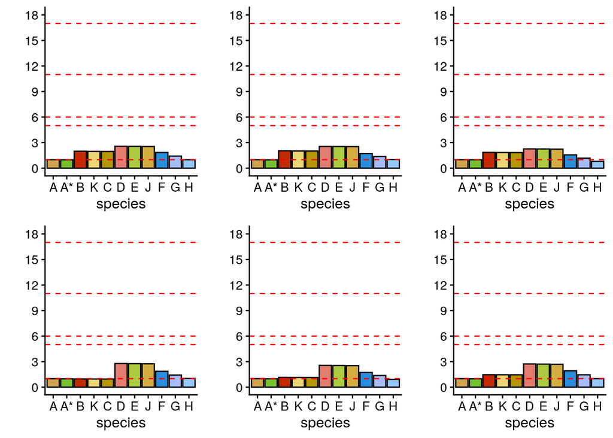

> Scenario D - Here is how the promoter values change over time

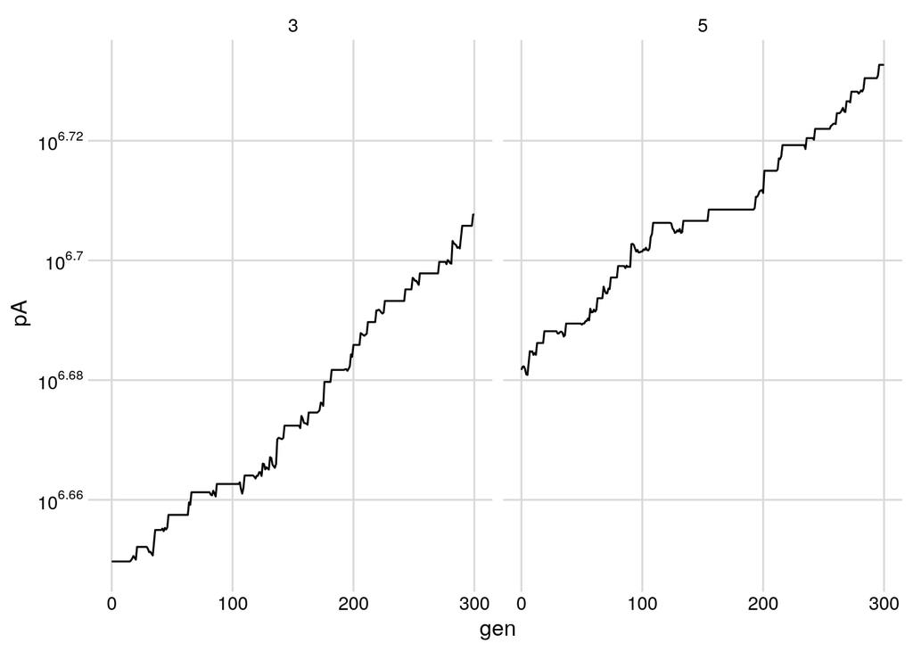

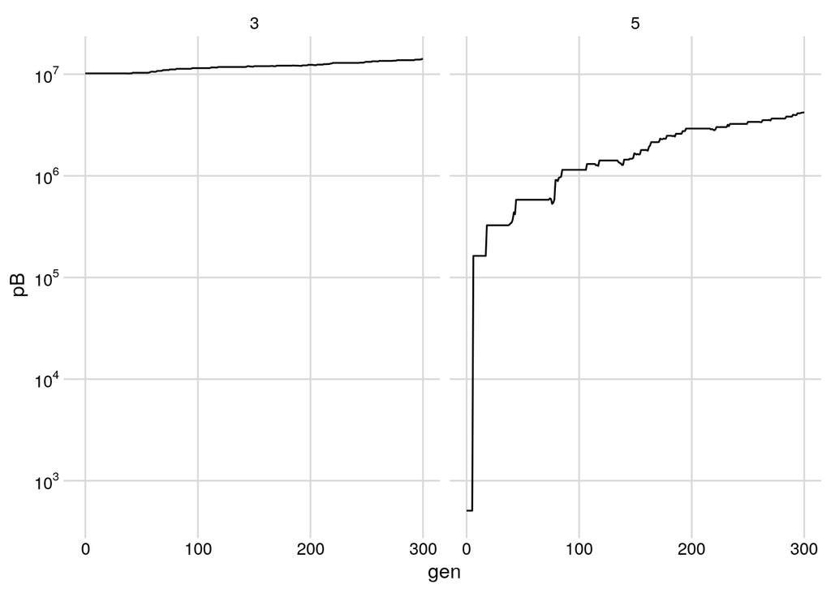

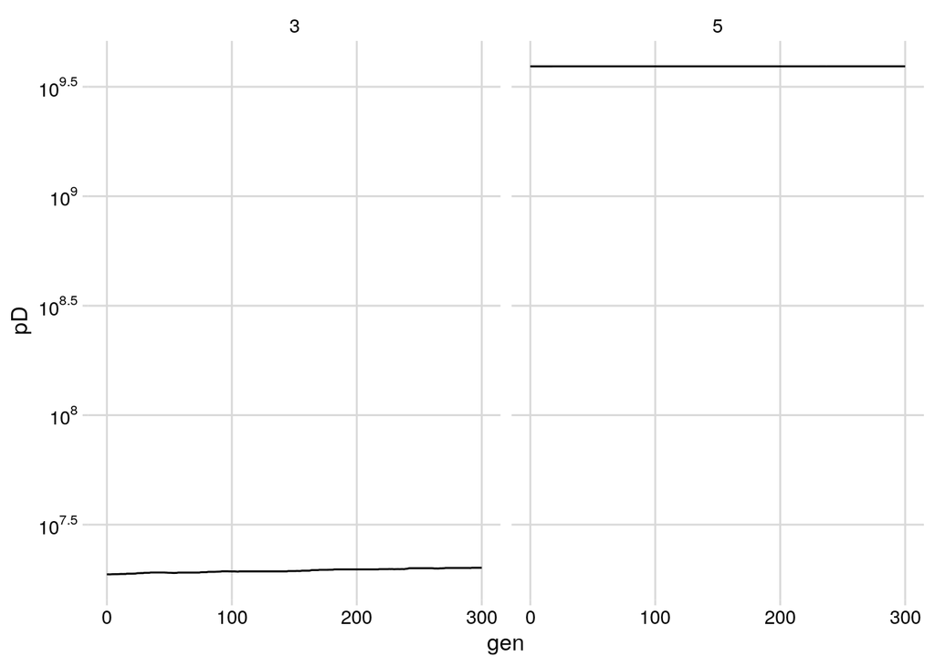

### **Scenario E**

> Scenario E - Change in Error over Generations

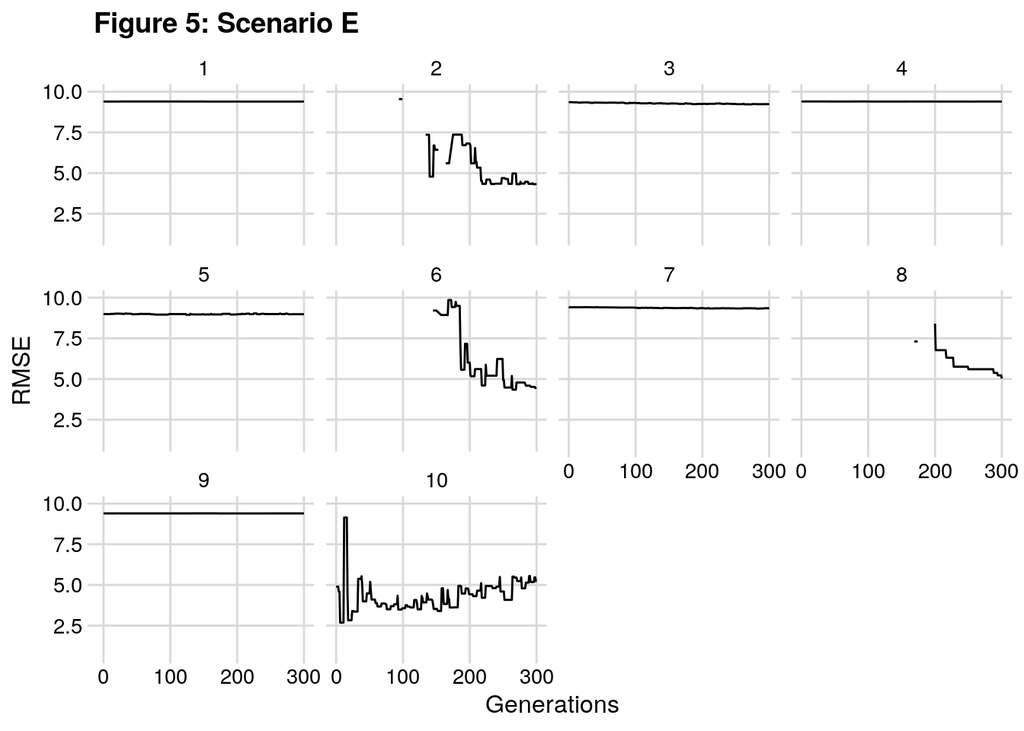

> Scenario E - Associated Errors for the best simulations

| sim | gen | pA | pB | pD | error |
| --- | --- | --- | --- | --- | --- |
| 2 | 270 | 761165.26 | 8.153309e+07 | 1400332.97 | 4.31620 |
| 2 | 300 | 831608.84 | 8.185860e+07 | 1482915.45 | 4.31990 |
| 6 | 264 | 681594.24 | 7.719626e+07 | 1495617.73 | 4.34377 |
| 6 | 300 | 730703.69 | 7.820028e+07 | 1583055.37 | 4.44613 |
| 8 | 300 | 682073.89 | 6.008755e+12 | 750959.68 | 5.02891 |
| 10 | 6 | 14391.03 | 5.139504e+04 | 75381.56 | 2.68413 |
| 10 | 300 | 669698.92 | 5.655099e+06 | 1791843.52 | 5.22900 |

> Scenario E - Final Transcript Abundances for the best sims

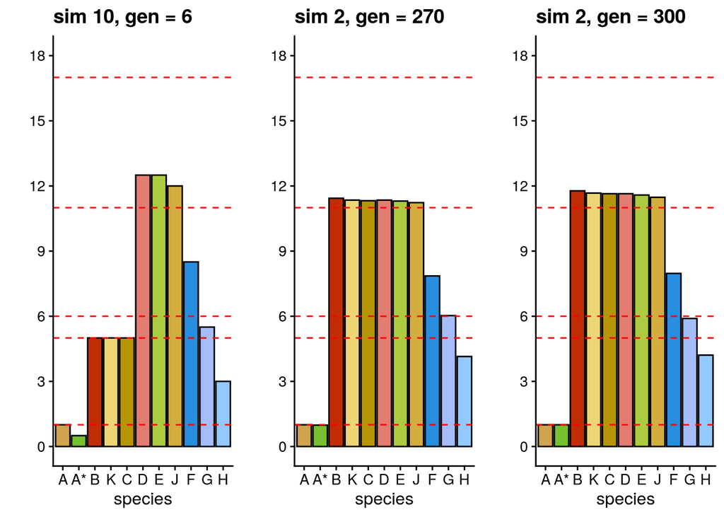

> Scenario E - Evolution of transcript abundances over generations for the best sims

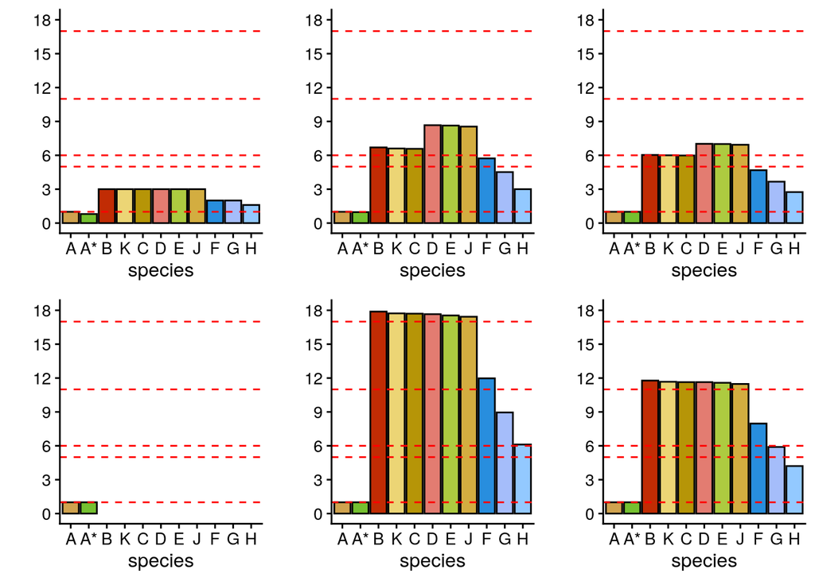

> Scenario E - Here is how the promoter values change over time

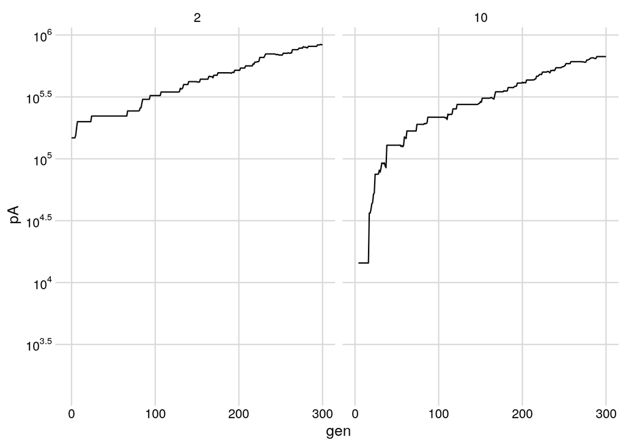

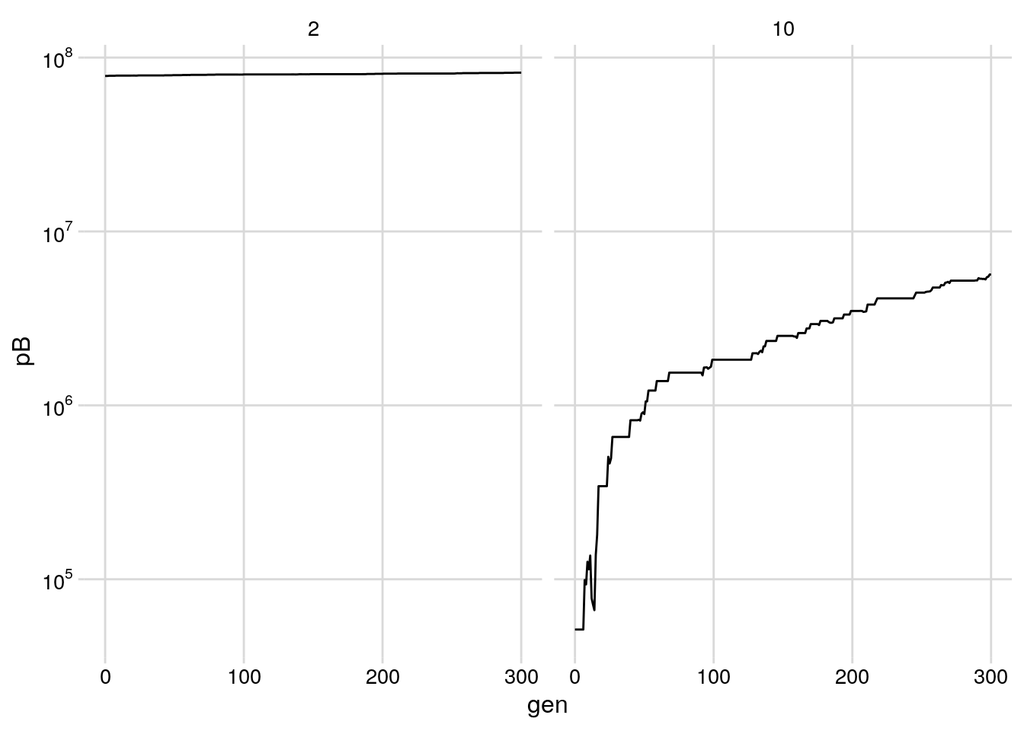

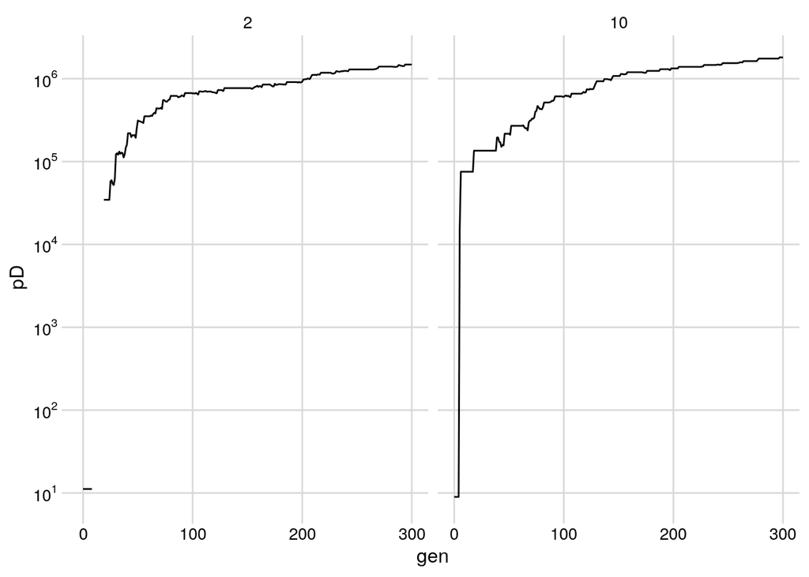